# Caregivers and PTSD Project Notebook

2026-02-09

## Load Packages

```r
library(tidyverse, quietly = TRUE) # Data wrangling
library(brms)      # Bayesian modeling
library(tidybayes) # For post-processing
library(cmdstanr)  # MCMC sampling
library(lavaan)    # Internal consistency
```

```r
library(dagitty)   # Specifying & Analyzing DAGs
library(ggdag)     # Drawing DAGs
library(ggtext)    # Fonts for graphs
library(showtext)  # To display fonts
library(posterior) # Extract posterior draws
```

## Import Data

```r
source(here::here("src/import.R"))
```

## MCMC Sampling

```r
options(mc.cores = parallel::detectCores())
options(brms.backend = "cmdstanr")
```

## Theme Settings

```r
font_add_google("Karla", family = "karla")
font_add_google("Cardo", family = "cardo")
showtext_auto()
colors_johnson <- MetBrewer::MetPalettes$Johnson[[1]]
c("#a00e00", "#d04e00", "#f6c200", "#0086a8", "#132b69")
```

```
## [1] "#a00e00" "#d04e00" "#f6c200" "#0086a8" "#132b69"
```

```r
theme_density <-
  theme(
    # Remove the legend
    legend.position = 'none',

    # Panel customization
    panel.background = element_rect(fill = "white", color = "white"),
    panel.grid.major.x = element_line(color = "#e9e9e9", linewidth = .3),
    panel.grid.minor.x = element_line(color = "#e9e9e9", linewidth = .1),
    panel.grid.major.y = element_blank(),

    # Axis customization
    #axis.line = element_line(color = "#3e3e3e"),
    axis.line.y.left = element_blank(),
    axis.title = element_markdown(size = 10, face = "bold"),
    axis.title.y = element_markdown(margin = margin(r = 20)),
    axis.text.y = element_blank(),
    axis.ticks = element_blank(),

    # Title customization
    plot.title = element_markdown(size = 14, face = "bold"),
    plot.subtitle = element_markdown(size = 12, color = "#3e3e3e"),
    plot.caption = element_markdown(hjust = 0, color = "#7e7e7e"),

    # Strip customization
    strip.background = element_rect(fill = "white"),
    strip.text = element_text(face = "bold")
  )
```

## Scientific Model

### The Initial Request

#### 1. PTSD and Depression, Anxiety, and Stress

> Depression/anxiety/stress (from DASS-21) levels in Caregivers with high PTSD vs. Caregivers with low PTSD (determined by mean-split).

> H1: Depression, Anxiety, and Stress will be significantly higher in caregivers with high probable PTSD than caregivers with low probable PTSD.
> - MANOVA
> - IV: PTSD group (High vs. Low)
> - DVs: DASS-21 Depression, Anxiety, Stress subscale scores (continuous)
> - Follow-up with univariate ANOVA for each DASS subscale.

#### 2. Burnout and PTSD

> Burnout (from BAT-12) in Caregivers with high PTSD vs. Caregivers with low PTSD(determined by mean-split).

> H2: Burnout will be significantly higher in caregivers with high probable PTSD than caregivers with low probable PTSD.
> - Independent samples t-test
> - IV: PTSD group (High vs. Low)
> - DV: Burnout score (BAT-12 total)
> - Report: t, p, Cohen’s d, confidence intervals, means

#### Veteran Caregivers and PTSD

> 3. Prevalence of probable PTSD (from PC-PTSD-5) in caregivers to veterans vs caregivers to non-veterans.

> H3: Probably PTSD will be more likely in caregivers to veterans than caregivers to non-veterans.
> - Chi-square test of independence
> - IV: Caregiver group (veteran caregiver vs. non-veteran caregiver)
> - DV: Probable PTSD status (yes/no)
> - Follow-up with binary logistic regression and include relevant covariates (age, sex, hrs caregiving/week, relationship with care recipient, military status).

#### Veteran Caregivers and Depression, Anxiety, and Stress

> 4. Depression/anxiety/stress levels (from DASS-21) in caregivers to veterans vs caregivers to non-veterans.

> H4: Depression, Anxiety, and Stress will be significantly higher in caregivers to veterans than caregivers to non-veterans.
> - MANOVA
> - IV: Caregiver group (veteran vs. non-veteran)
> - DVs: DASS-21 Depression, Anxiety, Stress subscale scores (continuous)
> - Follow-up with univariate ANOVA for each DASS subscale.

### My take on this:

1, 3, and 4 are quite coherent. They concern PTSD, veteran status of care recipient, and depression, anxiety, and stress. 2 regards burnout and is somewhat tangential. Burnout could be combined into the bigger model, but then the question comes: is it downstream from stress/anxiety/depression, or a mediator, or a moderator or what? And the cross-sectional data don’t support disentangling this.

The MANOVA angle makes sense. Stress, depression, and anxiety can be caused by traumatic stress disorders such as PTSD.

But stress, depression, and anxiety are correlated mental health issues; they tend to hang together. Moreover, people differ in personal traits that can affect these different issues simultaneously.

Given these individual traits, a person might tend to score high on stress, anxiety, and depression relative to what PTSD status alone would predict. So we need to model these 3 outcomes together, all predicted by PTSD, but also allowed for the part that isn’t predicted by PTSD (i.e., “error”) to co-vary apart from PTSD.

Now, to consider the veteran variable. It is defensible that having a veteran care recipient might be associated with PTSD because of secondary traumatic stress from a traumatic incident that befell; or because the veteran is more likely to experience trauma after leaving the service, the caregiver might be with them at the time.

The V->P temporal order is defensible and often assumed. But it too is confounded by childhood experiences that influence both the propensity to join the military and trauma response. Veterans research has not accounted for these pre-service confounders, to my knowledge, likely due to the difficulty of obtaining that data reliably.

### Estimands

Difference in stress, depression, and anxiety between caregivers to veterans and non-veterans. Difference in PTSD between caregivers to veterans and non-veterans.

## Examine Measures

### Depression DASS-21

```r
fit_depression <-
  lavaan::cfa(model = "depression =~ dass_3 + dass_5 + dass_10 + dass_13 + dass_16 + dass_17 + dass_21",
              data,
              std.lv = TRUE,
              ordered = c('dass_3','dass_5','dass_10',
                          'dass_13','dass_16','dass_17',
                          'dass_21'),
              estimator = "WLSMV")
reliability_depression <-
  semTools::compRelSEM(fit_depression,
                       obs.var = TRUE,
                       tau.eq = FALSE,
                       ord.scale = TRUE,
                       return.df = TRUE)
reliability_depression
```

```
## depression
##       0.93
```

### Anxiety DASS-21

```r
str_items <- paste0("DASS", c(1,6,8,11,12,14,18))

fit_anxiety <-
  lavaan::cfa(model = "anxiety =~ dass_2 + dass_4 + dass_7 + dass_9 + dass_15 + dass_19 + dass_20",
              data,
              std.lv = TRUE,
              ordered = c('dass_2','dass_4','dass_7',
                          'dass_9','dass_15','dass_19',
                          'dass_20'),
              estimator = "WLSMV")
reliability_anxiety <-
  semTools::compRelSEM(fit_anxiety,
                       obs.var = TRUE,
                       tau.eq = FALSE,
                       ord.scale = TRUE,
                       return.df = TRUE)
reliability_anxiety
```

```
## anxiety
##   0.926
```

### Stress DASS-21

```r
fit_stress <-
  lavaan::cfa(model = "stress =~ dass_1 + dass_6 + dass_8 + dass_11 + dass_12 + dass_14 + dass_18",
              data,
              std.lv = TRUE,
              ordered = c('dass_1','dass_6','dass_8',
                          'dass_11','dass_12','dass_14',
                          'dass_18'),
              estimator = "WLSMV")
reliability_stress <-
  semTools::compRelSEM(fit_stress,
                       obs.var = TRUE,
                       tau.eq = FALSE,
                       ord.scale = TRUE,
                       return.df = TRUE)
reliability_stress
```

```
## stress
##  0.913
```

## Examine Variables

### PTSD

```r
data %>% count(care_military, pc_ptsd_positive_screen)
```

```
## # A tibble: 4 × 3
##   care_military pc_ptsd_positive_screen     n
##           <dbl>                   <dbl> <int>
## 1             0                       0   155
## 2             0                       1    53
## 3             1                       0    34
## 4             1                       1    28
```

### Generative Model

With frequentist stats, this would be a MANOVA. A MANOVA is basically a multivariate outcome model with correlated residuals.

Let’s fit a multivariate Bayesian regression with correlated residuals across stress, anxiety, and depression.

This will account for shared variance among the outcomes and yield outcome-specific effects analogous to follow-up ANOVAs.

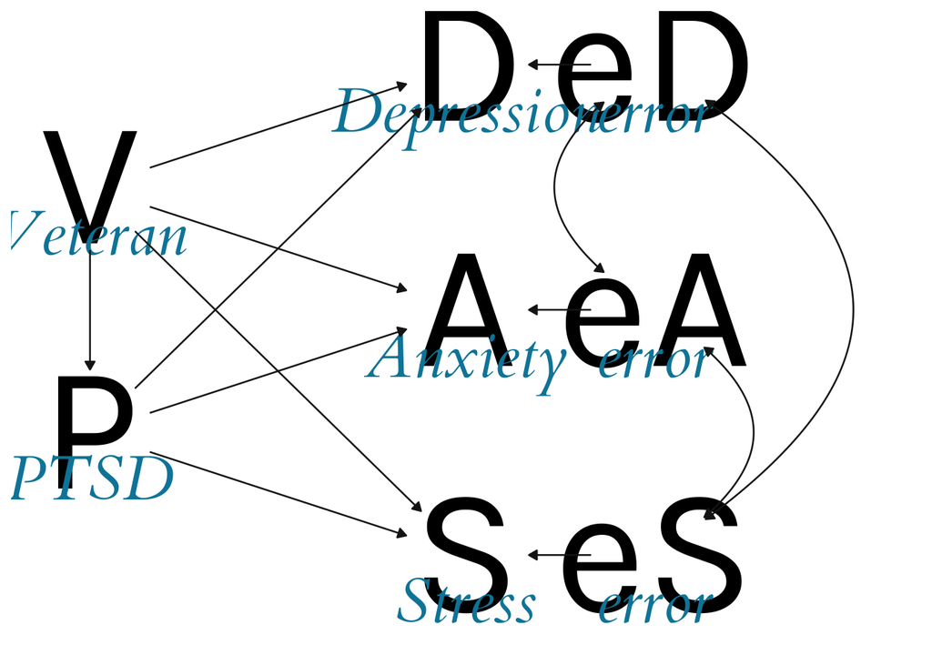

```r
dag_1 <-
  dagify(
    P ~ V,
    D ~ P + eD + V,
    A ~ P + eA + V,
    S ~ P + eS + V,
    eS ~~ eA,
    eD ~~ eS,
    eA ~~ eD,
    exposure = 'P',
    coords = list(
    x = c(V = -.1, P =  -.1, D =   0, A = 0, S =   0, eD = .05, eA = .05, eS =  .05),
    y = c(V = .05, P = -.05, D =  .1, A = 0, S = -.1, eD = .1, eA =  0, eS = -.1))
)

dag_1 %>%
  tidy_dagitty() %>%
  mutate(
    label = case_when(
      name == "V" ~ "Veteran",
      name == "P" ~ "PTSD",
      name == "D" ~ "Depression",
      name == "A" ~ "Anxiety",
      name == "S" ~ "Stress",
      name == "eD" ~ "error",
      name == "eA" ~ "error",
      name == "eS" ~ "error",
      .default = name)
    ) %>%
  ggplot(aes(x = .data$x, y = .data$y, xend = .data$xend, yend = .data$yend)) +
  #geom_dag_point(color = 'white') +
  geom_dag_text(color = 'black', size = 34, family = "karla", fontface = "plain") +
  geom_dag_text(aes(label = label), size = 12, color = colors_johnson[4], nudge_y = -.0185, nudge_x = -.000005, fontface = "italic", family = "cardo") +
  geom_dag_edges(
    data_directed = dag_1 %>% tidy_dagitty() %>% filter(direction == "->"),
    curvature = .5,
    start_cap = ggraph::circle(12, 'mm'),
    end_cap = ggraph::circle(12, 'mm'),
    edge_color = "grey10",
    edge_width = .45
    ) +
  theme_dag_blank() +
  lims(x = c(-.11,.11))
```

```r
ggsave(here::here('output/dag.jpg'), height = 4, width = 6)
```

One important implication of this DAG is that PTSD is positioned as a pipe (i.e., a mediator). If we model PTSD alongside veteran status, then the coefficient on Veteran can only be interpreted as a direct effect, not a total effect.

#### Likelihood

This means the likelihood of the joint outcome $y_i$ is modeled as a multivariate normal distribution with parameters $\mu$ and $\Sigma$.

$$\begin{align}
& y_i \sim MVNormal(\mu_i, \Sigma) \\
\end{align}$$

$\mu_i$ is modeled as a vector of comprised of the factor of predictor variables ${x}_i^{\top}$ and the regression coefficients for each outcome $\beta_1, \beta_2, \beta_3$.

$$\begin{align}
\mu_i =
\begin{pmatrix}
\alpha_s + \beta_{sV} V_i + \beta_{sP} P_i \\
\alpha_s + \beta_{aV} V_i + \beta_{aP} P_i \\
\alpha_s + \beta_{dV} V_i + \beta_{dP} P_i
\end{pmatrix}
\end{align}$$

$\Sigma$ is a residual covariance matrix

$$\Sigma =
\begin{pmatrix}
\sigma_1^2 & \rho_{12}\sigma_1\sigma_2 &
\rho_{13}\sigma_1\sigma_3 \\
\rho_{12}\sigma_1\sigma_2 & \sigma_2^2 &
\rho_{23}\sigma_2\sigma_3 \\
\rho_{13}\sigma_1\sigma_3 & \rho_{23}\sigma_2\sigma_3 &
\sigma_3^2
\end{pmatrix}$$

Where $\rho_{12}, \rho_{23}, \rho_{13}$ are the correlated residuals between outcomes – the extent to which the variation in the outcomes not explained by the IVs is shared among the DVs – and $\sigma_1, \sigma_2, \sigma_3$ the standard deviations of the residuals which are the unique, unshared error of each outcome.

#### Priors

When determining priors, always consider the scale of the variables.

The predictor variables are binary 0-1: Non-Veteran/Veteran and No PTSD/PTSD. The 0 represents the absence of Veteran status or PTSD.

We will standardize the outcomes to make selecting priors easier. This also makes the coefficient standardized rather than unstandardized (e.g., $b$ to $beta$).

The intercept represents the mean for the reference group (0s). The beta represents the difference between groups (0-1). $\text{Normal}(0, .5)$ is reasonable for both. That means I think the predicted outcome of the reference group will be +-1SD of the mean in most cases, and most likely within -+0.5 SD. The same for the difference between group means.

##### Standardize the variables

```r
data <-
  data %>%
  mutate(dass_depression_z = as.numeric(scale(dass_depression)),
         dass_stress_z = as.numeric(scale(dass_stress)),
         dass_anxiety_z = as.numeric(scale(dass_anxiety)))
```

For the prior on the standard error $\sigma$, we need a positive real number, because standard errors are always positive. By standardizing the outcome variables, the variables have been scaled to have a SD = 1. So the prior should be something make make 1 and the values near it highly plausible. Say a half-student-t(3, 0, 1) or a half-Cauchy(0,1)

For the prior on the residual covariance, I’ll use the $\text{LJKcorr}(2)$ which is a standard choice for covariance matrices (McElreath, 2015) and is more skeptical of extreme correlations near 1 or -1 than it is correaltions closer to 0.

$$\begin{align}
& \beta \sim \text{Normal}(0, .5) \\
& \alpha \sim \text{Normal}(0, .5) \\
& \sigma \sim \text{half-Student-t}(3, 0, 1) \\
& \Sigma \sim \text{LJKcorr}(2) \\ \\
\end{align}$$

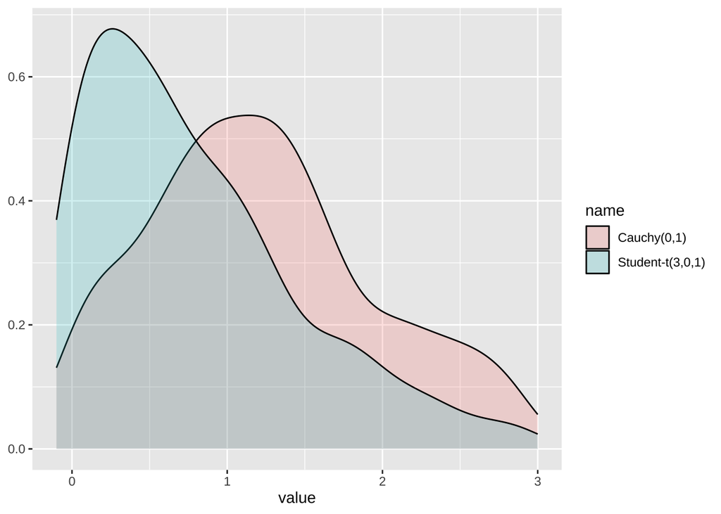

```r
tibble(`Cauchy(0,1)` = rcauchy(1000, 1, 1),
       `Student-t(3,0,1)` = rstudent_t(n = 1000, 3, 0, 1)) %>% pivot_longer(everything()) %>%  ggplot(aes(value, fill = name)) + geom_density(alpha = .2) + lims(x = c(-.1, 3)) + labs(y = NULL)
```

### Computer Model

#### Simulation Model

```r
library(tibble)
library(MASS)  # mvrnorm
set.seed(1)
n <- 200

# predictor
x1 <- rbinom(n, size = 1, prob = .5)
x2 <- rbinom(n, size = 1, prob = .5)

# regression coefficients (one per outcome)
beta_1 <- c(d = 0.5, s = 0.3, a = 0.2)
beta_2 <- c(d = 0.5, s = 0.3, a = 0.2)

# residual covariance
Sigma <- matrix(
  c(1.0, 0.6, 0.5,
    0.6, 1.0, 0.4,
    0.5, 0.4, 1.0),
  nrow = 3
)

# correlated errors
E <- MASS::mvrnorm(n, mu = c(0, 0, 0), Sigma = Sigma)

# outcomes
data_sim <-
  tibble(
    pc_ptsd_positive_screen = x1,
    caregivee_military = x2,
    dass_depression_z = beta_1["d"] * x1 + beta_2["d"] * x2 + E[,1],
    dass_stress_z = beta_1["s"] * x1 + beta_2["s"] * x2 + E[,2],
    dass_anxiety_z = beta_1["a"] * x1 + beta_2["a"] * x2 + E[,3]
)
```

#### Set Priors

```r
priors <- c(
  # Residual correlation shrinkage
  prior(lkj(2), class = "rescor"),

  # Stress
  prior(normal(0, .5), class = "Intercept", resp = "dassstressz"),
  prior(normal(0, .5), class = "b", resp = "dassstressz"),
  prior(student_t(3, 0, 1), class = "sigma", resp = "dassstressz"),

  # Anxiety
  prior(normal(0, .5), class = "Intercept", resp = "dassanxietyz"),
  prior(normal(0, .5), class = "b", resp = "dassanxietyz"),
  prior(student_t(3, 0, 1), class = "sigma", resp = "dassanxietyz"),

  # Depression
  prior(normal(0, .5), class = "Intercept", resp = "dassdepressionz"),
  prior(normal(0, .5), class = "b", resp = "dassdepressionz"),
  prior(student_t(3, 0, 1), class = "sigma", resp = "dassdepressionz")
)
```

#### Fit the simulation data to the model

```r
fit_manova_simulation <-
  brm(
    bf(dass_stress_z ~ 1 + pc_ptsd_positive_screen + caregivee_military) +
    bf(dass_anxiety_z ~ 1 + pc_ptsd_positive_screen + caregivee_military) +
    bf(dass_depression_z ~ 1 + pc_ptsd_positive_screen + caregivee_military) +
    set_rescor(TRUE),
  prior = priors,
  data = data_sim,
  family = gaussian(),
  chains = 4, cores = 4, warmup = 2000, iter = 6000
)
```

[output not shown]

[output cut: 203 more lines]

[output not shown]

```r
fit_logistic_simulation <-
  brm(
    bf(pc_ptsd_positive_screen ~ 1 + caregivee_military, family = bernoulli(link = "logit")),
  prior = c(
    prior(normal(0, .5), class = "Intercept"),
    prior(normal(0, .5), class = "b")
  ),
  data = data_sim,
  family = bernoulli(link = "logit"),
  chains = 4, cores = 4, warmup = 2000, iter = 6000
)
```

[output not shown]

[output cut: 203 more lines]

[output not shown]

```r
fit_manova_simulation
```

```
##  Family: MV(gaussian, gaussian, gaussian)
##   Links: mu = identity
##          mu = identity
##          mu = identity
## Formula: dass_stress_z ~ 1 + pc_ptsd_positive_screen + caregivee_military
##          dass_anxiety_z ~ 1 + pc_ptsd_positive_screen + caregivee_military
##          dass_depression_z ~ 1 + pc_ptsd_positive_screen + caregivee_military
##    Data: data_sim (Number of observations: 200)
##   Draws: 4 chains, each with iter = 6000; warmup = 2000; thin = 1;
##          total post-warmup draws = 16000
##
## Regression Coefficients:
##                                         Estimate Est.Error l-95% CI u-95% CI
## dassstressz_Intercept                       0.15      0.11    -0.07     0.36
## dassanxietyz_Intercept                     -0.02      0.11    -0.24     0.21
## dassdepressionz_Intercept                   0.06      0.11    -0.16     0.28
## dassstressz_pc_ptsd_positive_screen         0.21      0.13    -0.05     0.48
## dassstressz_caregivee_military              0.07      0.14    -0.20     0.35
## dassanxietyz_pc_ptsd_positive_screen        0.22      0.14    -0.07     0.50
## dassanxietyz_caregivee_military             0.10      0.14    -0.19     0.37
## dassdepressionz_pc_ptsd_positive_screen     0.37      0.14     0.10     0.64
## dassdepressionz_caregivee_military          0.30      0.14     0.02     0.57
##                                         Rhat Bulk_ESS Tail_ESS
## dassstressz_Intercept                   1.00    18108    13800
## dassanxietyz_Intercept                  1.00    19580    12570
## dassdepressionz_Intercept               1.00    17513    12557
## dassstressz_pc_ptsd_positive_screen     1.00    16805    13162
## dassstressz_caregivee_military          1.00    17263    13950
## dassanxietyz_pc_ptsd_positive_screen    1.00    19123    12718
## dassanxietyz_caregivee_military         1.00    19043    13246
## dassdepressionz_pc_ptsd_positive_screen 1.00    16316    12711
## dassdepressionz_caregivee_military      1.00    15722    12503
##
## Further Distributional Parameters:
##                       Estimate Est.Error l-95% CI u-95% CI Rhat Bulk_ESS
## sigma_dassstressz         1.02      0.05     0.92     1.12 1.00    19674
## sigma_dassanxietyz        1.06      0.05     0.96     1.17 1.00    21441
## sigma_dassdepressionz     1.03      0.05     0.94     1.14 1.00    19608
##                       Tail_ESS
## sigma_dassstressz        13212
## sigma_dassanxietyz       11776
## sigma_dassdepressionz    12381
##
## Residual Correlations:
##                                      Estimate Est.Error l-95% CI u-95% CI Rhat
## rescor(dassstressz,dassanxietyz)         0.35      0.06     0.23     0.47 1.00
## rescor(dassstressz,dassdepressionz)      0.54      0.05     0.43     0.63 1.00
## rescor(dassanxietyz,dassdepressionz)     0.44      0.06     0.32     0.54 1.00
##                                      Bulk_ESS Tail_ESS
## rescor(dassstressz,dassanxietyz)        18290    12281
## rescor(dassstressz,dassdepressionz)     17346    13310
## rescor(dassanxietyz,dassdepressionz)    19593    13029
##
## Draws were sampled using sample(hmc). For each parameter, Bulk_ESS
## and Tail_ESS are effective sample size measures, and Rhat is the potential
## scale reduction factor on split chains (at convergence, Rhat = 1).
```

```r
fit_logistic_simulation
```

```
##  Family: bernoulli
##   Links: mu = logit
## Formula: pc_ptsd_positive_screen ~ 1 + caregivee_military
##    Data: data_sim (Number of observations: 200)
##   Draws: 4 chains, each with iter = 6000; warmup = 2000; thin = 1;
##          total post-warmup draws = 16000
##
## Regression Coefficients:
##                    Estimate Est.Error l-95% CI u-95% CI Rhat Bulk_ESS Tail_ESS
## Intercept             -0.13      0.17    -0.47     0.21 1.00    12464    10349
## caregivee_military     0.42      0.25    -0.07     0.91 1.00    14046    10534
##
## Draws were sampled using sample(hmc). For each parameter, Bulk_ESS
## and Tail_ESS are effective sample size measures, and Rhat is the potential
## scale reduction factor on split chains (at convergence, Rhat = 1).
```

The model did a decent job recovering the parameters of the simulated data.

Plot the posterior residual covariance from the model of simulated data.

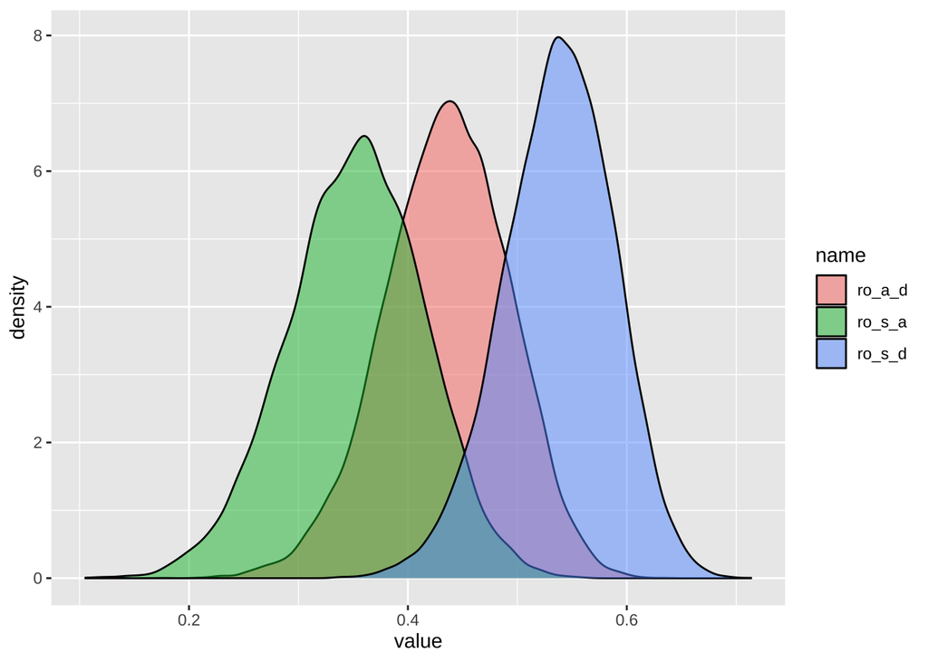

```r
fit_manova_simulation %>%
  tidy_draws() %>%
  dplyr::select(contains('rescor')) %>%
  rename(ro_s_a = rescor__dassstressz__dassanxietyz,
         ro_s_d = rescor__dassstressz__dassdepressionz,
         ro_a_d = rescor__dassanxietyz__dassdepressionz) %>%
  pivot_longer(everything()) %>%
  ggplot(aes(value, fill = name)) +
  geom_density(alpha = .5)
```

##### Try it with stan

One issue is that brms has problems fitting both models simultaneously. It can’t do the residual correlation on only the continuous variables – it also want to do the logistic variable.

```r
stan_data <-
  list(
    N = nrow(data_sim),
    #X = as.matrix(data_sim %>% dplyr::select(pc_ptsd_positive_screen, caregivee_military) %>% rename(P = 1, V = 2)),
    #K = c(2),
    V = data_sim$caregivee_military,
    P = data_sim$pc_ptsd_positive_screen,
    Y = as.matrix(
    data_sim[, c("dass_stress_z",
                 "dass_anxiety_z",
                 "dass_depression_z")])
  )

# Compile the stan code
mod <- cmdstan_model("model.stan")

# Fit the model
fit <- mod$sample(
  data = stan_data,
  chains = 4,
  parallel_chains = 4,
  iter_warmup = 2000,
  iter_sampling = 6000,
  seed = 5000
)
```

```
## Running MCMC with 4 parallel chains...
##
## Chain 1 Iteration:    1 / 8000 [  0%]  (Warmup)
```

[output not shown]

[output not shown]

[output not shown]

[output not shown]

[output not shown]

[output not shown]

[output not shown]

[output not shown]

[output not shown]

[output not shown]

[output not shown]

[output not shown]

[output not shown]

[output not shown]

[output not shown]

[output not shown]

[output not shown]

[output not shown]

[output not shown]

[output not shown]

[output not shown]

[output not shown]

[output not shown]

[output not shown]

[output not shown]

[output not shown]

[output not shown]

[output not shown]

[output not shown]

[output not shown]

[output not shown]

[output not shown]

[output not shown]

[output not shown]

[output not shown]

[output not shown]

[output not shown]

[output not shown]

[output not shown]

[output not shown]

[output not shown]

[output not shown]

[output not shown]

[output not shown]

[output not shown]

[output not shown]

[output not shown]

[output not shown]

[output not shown]

[output not shown]

[output not shown]

[output not shown]

[output not shown]

[output not shown]

[output not shown]

[output not shown]

[output not shown]

[output not shown]

[output not shown]

[output not shown]

[output not shown]

[output not shown]

[output not shown]

[output not shown]

[output not shown]

[output not shown]

[output not shown]

[output not shown]

[output not shown]

[output not shown]

[output not shown]

[output not shown]

[output not shown]

[output not shown]

[output not shown]

[output not shown]

[output not shown]

[output not shown]

[output not shown]

[output not shown]

[output not shown]

[output not shown]

[output not shown]

[output not shown]

[output not shown]

[output not shown]

[output not shown]

[output not shown]

[output not shown]

[output not shown]

[output not shown]

[output not shown]

[output not shown]

[output not shown]

[output not shown]

[output not shown]

[output not shown]

[output not shown]

[output not shown]

[output not shown]

[output not shown]

[output not shown]

[output not shown]

[output not shown]

[output not shown]

[output not shown]

[output not shown]

[output not shown]

[output not shown]

[output not shown]

[output not shown]

[output not shown]

[output not shown]

[output not shown]

[output not shown]

[output not shown]

[output not shown]

[output not shown]

[output not shown]

[output not shown]

[output not shown]

[output not shown]

[output not shown]

[output not shown]

[output not shown]

[output not shown]

[output not shown]

[output not shown]

[output not shown]

[output not shown]

[output not shown]

[output not shown]

[output not shown]

[output not shown]

[output not shown]

[output not shown]

[output not shown]

[output not shown]

[output not shown]

[output not shown]

[output not shown]

[output not shown]

[output not shown]

[output not shown]

[output not shown]

[output not shown]

[output not shown]

[output not shown]

[output not shown]

[output not shown]

[output not shown]

[output not shown]

[output not shown]

[output not shown]

[output not shown]

[output not shown]

[output not shown]

[output not shown]

[output not shown]

[output not shown]

[output not shown]

[output not shown]

[output not shown]

[output not shown]

[output not shown]

[output not shown]

[output not shown]

[output not shown]

[output not shown]

[output not shown]

[output not shown]

[output not shown]

[output not shown]

[output not shown]

[output not shown]

[output not shown]

[output not shown]

[output not shown]

[output not shown]

[output cut: 277 more lines]

[output not shown]

#### Check Sampling Diagnoses

```r
fit$cmdstan_diagnose()
```

```
## Checking sampler transitions treedepth.
## Treedepth satisfactory for all transitions.
##
## Checking sampler transitions for divergences.
## No divergent transitions found.
##
## Checking E-BFMI - sampler transitions HMC potential energy.
## E-BFMI satisfactory.
##
## Rank-normalized split effective sample size satisfactory for all parameters.
##
## Rank-normalized split R-hat values satisfactory for all parameters.
##
## Processing complete, no problems detected.
```

#### Extract posterior draws

```r
draws <- fit$draws() %>% as_draws_df() %>% tibble()
draws %>% names()
```

```
##   [1] "lp__"         "alpha_P"      "gamma_V"      "alpha_Y[1]"   "alpha_Y[2]"
##   [6] "alpha_Y[3]"   "beta_V[1]"    "beta_V[2]"    "beta_V[3]"    "beta_P[1]"
##  [11] "beta_P[2]"    "beta_P[3]"    "sigma[1]"     "sigma[2]"     "sigma[3]"
##  [16] "Lcorr[1,1]"   "Lcorr[2,1]"   "Lcorr[3,1]"   "Lcorr[1,2]"   "Lcorr[2,2]"
##  [21] "Lcorr[3,2]"   "Lcorr[1,3]"   "Lcorr[2,3]"   "Lcorr[3,3]"   "L_Sigma[1,1]"
##  [26] "L_Sigma[2,1]" "L_Sigma[3,1]" "L_Sigma[1,2]" "L_Sigma[2,2]" "L_Sigma[3,2]"
##  [31] "L_Sigma[1,3]" "L_Sigma[2,3]" "L_Sigma[3,3]" "R[1,1]"       "R[2,1]"
##  [36] "R[3,1]"       "R[1,2]"       "R[2,2]"       "R[3,2]"       "R[1,3]"
##  [41] "R[2,3]"       "R[3,3]"       "Sigma[1,1]"   "Sigma[2,1]"   "Sigma[3,1]"
##  [46] "Sigma[1,2]"   "Sigma[2,2]"   "Sigma[3,2]"   "Sigma[1,3]"   "Sigma[2,3]"
##  [51] "Sigma[3,3]"   "Y_rep[1,1]"   "Y_rep[2,1]"   "Y_rep[3,1]"   "Y_rep[4,1]"
##  [56] "Y_rep[5,1]"   "Y_rep[6,1]"   "Y_rep[7,1]"   "Y_rep[8,1]"   "Y_rep[9,1]"
##  [61] "Y_rep[10,1]"  "Y_rep[11,1]"  "Y_rep[12,1]"  "Y_rep[13,1]"  "Y_rep[14,1]"
##  [66] "Y_rep[15,1]"  "Y_rep[16,1]"  "Y_rep[17,1]"  "Y_rep[18,1]"  "Y_rep[19,1]"
##  [71] "Y_rep[20,1]"  "Y_rep[21,1]"  "Y_rep[22,1]"  "Y_rep[23,1]"  "Y_rep[24,1]"
```

[output cut: 156 more lines]

```r
draws <- draws %>% dplyr::select(!contains('Y_rep') & !contains('p_ptsd'))

# Fix names
replacements <- c("1" = "S",
                  "2" = "A",
                  "3" = "D",
                  "\\," = "_",
                  "\\[" = "_",
                  "\\]" = "")
names(draws) <- str_replace_all(names(draws), replacements)

# get rid of self-correlation = 1
draws <- draws %>% dplyr::select(-c(R_A_A, R_S_S, R_D_D))
```

```r
draws
```

```
## # A tibble: 24,000 × 51
##     lp__ alpha_P gamma_V alpha_Y_S alpha_Y_A alpha_Y_D beta_V_S beta_V_A
##    <dbl>   <dbl>   <dbl>     <dbl>     <dbl>     <dbl>    <dbl>    <dbl>
##  1 -399. -0.0917   0.327    0.123     0.112     0.107    0.0894 -0.269
##  2 -401. -0.360    0.530    0.249     0.0271    0.101    0.157   0.166
##  3 -402. -0.178    0.242    0.0420   -0.195    -0.0131   0.0356  0.120
##  4 -400. -0.218    0.733    0.0161    0.0219   -0.0718   0.0768  0.103
##  5 -403. -0.447    0.818    0.183     0.0179    0.255    0.0269 -0.00857
##  6 -403. -0.130    0.609    0.119    -0.127    -0.160    0.105   0.156
##  7 -406. -0.115    0.829    0.171    -0.0187    0.181    0.207   0.156
##  8 -403. -0.132    0.274    0.0691   -0.206    -0.104    0.273   0.271
##  9 -405. -0.0572   0.508   -0.0498    0.101    -0.0583   0.231   0.218
## 10 -405. -0.0493   0.430   -0.0151    0.115    -0.0428   0.144   0.188
## # ℹ 23,990 more rows
## # ℹ 43 more variables: beta_V_D <dbl>, beta_P_S <dbl>, beta_P_A <dbl>,
## #   beta_P_D <dbl>, sigma_S <dbl>, sigma_A <dbl>, sigma_D <dbl>,
## #   Lcorr_S_S <dbl>, Lcorr_A_S <dbl>, Lcorr_D_S <dbl>, Lcorr_S_A <dbl>,
## #   Lcorr_A_A <dbl>, Lcorr_D_A <dbl>, Lcorr_S_D <dbl>, Lcorr_A_D <dbl>,
## #   Lcorr_D_D <dbl>, L_Sigma_S_S <dbl>, L_Sigma_A_S <dbl>, L_Sigma_D_S <dbl>,
## #   L_Sigma_S_A <dbl>, L_Sigma_A_A <dbl>, L_Sigma_D_A <dbl>, …
```

#### Poterior Predictions

Difference in posterior predictions for ‘total effect’ under do(V=v). Where PTSD is considered a function of veteran, like in the generative model.

```r
# Extract the Sigma from each draw
Sigma_list <-
  draws %>%
  transmute(
    sSS = Sigma_S_S, sSA = Sigma_S_A, sSD = Sigma_S_D,
    sAS = Sigma_A_S, sAA = Sigma_A_A, sAD = Sigma_A_D,
    sDS = Sigma_D_S, sDA = Sigma_D_A, sDD = Sigma_D_D
  ) %>%
  pmap(function(sSS, sSA, sSD, sAS, sAA, sAD, sDS, sDA, sDD) {
    matrix(c(
      sSS, sSA, sSD,
      sAS, sAA, sAD,
      sDS, sDA, sDD
    ), nrow = 3, byrow = TRUE)
  })
```

```r
inv_logit <- function(x) 1 / (1 + exp(-x))

ppred_doV_one_per_draw <- function(draws, Sigma_list, v) {

  outcome_names <- c("stress", "anxiety", "depression")

  # per-draw PTSD probability under do(V=v)
  w <- inv_logit(draws$alpha_P + draws$gamma_V * v)

  # sample PTSD for the new person within each posterior draw
  P_new <- rbinom(n = length(w), size = 1, prob = w)

  # per-draw mean vectors mu(v, P_new)
  mu_mat <- draws %>%
    transmute(
      stress     = alpha_Y_S + beta_V_S * v + beta_P_S * P_new,
      anxiety    = alpha_Y_A + beta_V_A * v + beta_P_A * P_new,
      depression = alpha_Y_D + beta_V_D * v + beta_P_D * P_new
    ) %>%
    as.matrix()

  # simulate Y_new ~ MVN(mu, Sigma) once per draw
  Yrep <- map2_dfr(
    split(mu_mat, row(mu_mat)),
    Sigma_list,
    ~ {
      y <- MASS::mvrnorm(1, mu = .x, Sigma = .y)
      y <- setNames(as.numeric(y), outcome_names)
      tibble::as_tibble_row(y)
    }
  )

  Yrep %>%
    mutate(
      V_do = v,
      P_new = P_new
    )
}


## simulate v1 and v0 and contrast
set.seed(1)

Y_v1 <- ppred_doV_one_per_draw(draws, Sigma_list, v = 1)
Y_v0 <- ppred_doV_one_per_draw(draws, Sigma_list, v = 0)

contrasts_do <- bind_cols(
  Y_v1 %>% dplyr::select(stress, anxiety, depression) %>% rename_with(~ paste0(.x, "_v1")),
  Y_v0 %>% dplyr::select(stress, anxiety, depression) %>% rename_with(~ paste0(.x, "_v0"))
) %>%
  transmute(
    stress     = stress_v1     - stress_v0,
    anxiety    = anxiety_v1    - anxiety_v0,
    depression = depression_v1 - depression_v0
  )
```

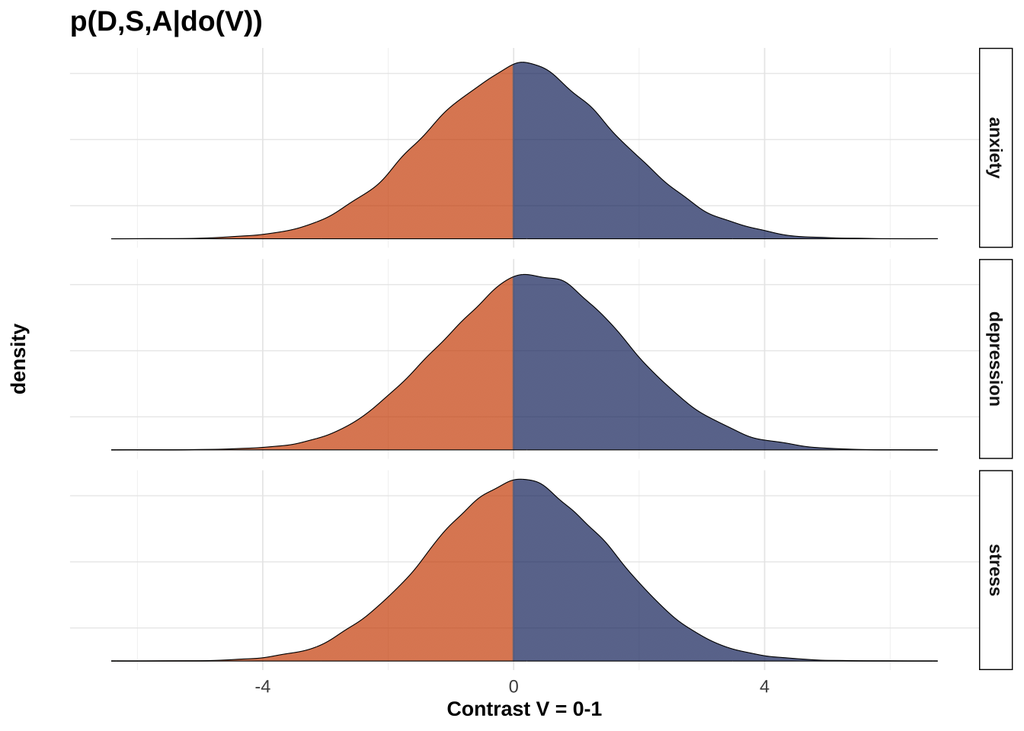

```r
contrasts_do %>%
  pivot_longer(everything()) %>%
  ggplot(aes(x = value)) +
  stat_density(aes(fill = after_stat(x > 0)), alpha = .7, color = 'black', size = .2) +
  scale_fill_manual(values = c("FALSE" = "#d04e00", "TRUE" = "#132b69"),
                    labels = c("Below/Equal 0", "Above 0")) +
  facet_grid(vars(name)) +
  theme_minimal() +
  labs(title = 'p(D,S,A|do(V))', x = 'Contrast V = 0-1', fill = "Condition") +
  theme_density
```

```r
contrasts_do %>%
  pivot_longer(everything()) %>%
  group_by(name) %>%
  mutate(veteran_greater = ifelse(value >0, 1, 0)) %>%
  summarize(perc_veteran_greater = mean(veteran_greater))
```

```
## # A tibble: 3 × 2
##   name       perc_veteran_greater
##   <chr>                     <dbl>
## 1 anxiety                   0.536
## 2 depression                0.589
## 3 stress                    0.529
```

## Write Up

### Results

- Warn against the table 2 fallacy, if applicable
- draw densities instead of intervals